# Lecture 2: Digital Marketing and Advertising Psychology

## Strategy and STP

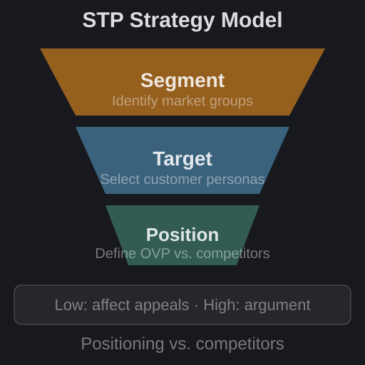

## Tactics: The Digital Mix

- `7Ps applied: Select optimal mix across the six digital media channels`
- Apply 7Ps: Product, Price, Place, Promotion, People, Process, Physical
- Low-involvement: push media such as display ads and video
- High-involvement: pull media (SEO, content) for proactive research
- Channel selection driven by audience behavior and budget allocation

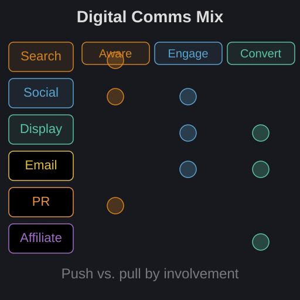

## Campaign Execution

- `Action planning: Develop campaign timeline and editorial content calendar`
- Manage multichannel communications across paid, owned, earned
- Low-involvement: seasonal ‘burst’ campaigns and real-time marketing
- High-involvement: always-on lifecycle communications
- Agile iteration: review results weekly and adapt creative

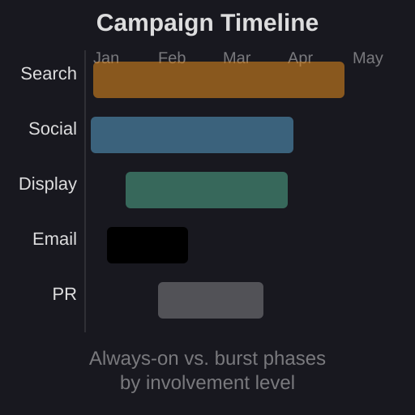

## Performance Control

- `Analytics and optimization: Use digital dashboards to track KPIs against SMART targets`
- Conduct AB testing continuously to optimize conversion
- Low-involvement control: reach and frequency metrics
- High-involvement control: attribution modeling for complex journeys
- Regular reporting cadence closes the feedback loop

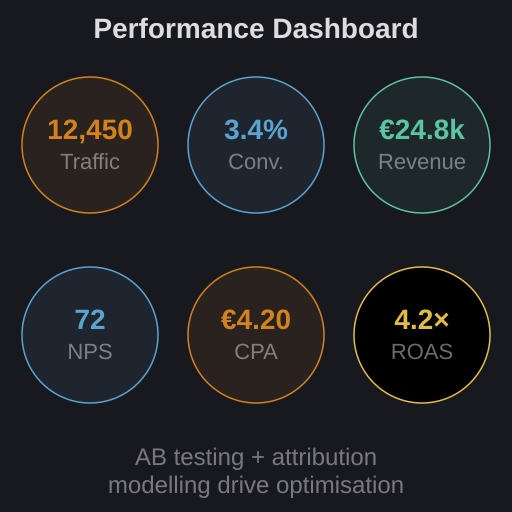